# ADSP 32018 - NLP - Assignment 6

## NLP Class Assignment 6

You have been provided with a starter notebook that reads a collection of tweets and a collection of news articles about one particular company. Use appropriate topic modeling technique to identify top N most important topics. To get quality results apply appropriate text cleaning methods.

- Present top N most important topics in the news articles and tweets
  - For news articles, consider how to effectively combine information from the title and text of news article
- Select N to identify relevant topics, but minimize duplication
- Explain how you selected N

Rules and requirements:

Your final output and the code should be contained within Jupyter Notebook (ipynb)

```python
import pandas as pd
import re
import spacy
from nltk.corpus import stopwords
from nltk.tokenize import word_tokenize
from nltk.stem import WordNetLemmatizer
from sklearn.feature_extraction.text import CountVectorizer
import gensim
from gensim import corpora, models
from gensim.models.ldamulticore import LdaMulticore
from gensim.utils import simple_preprocess
from gensim.models import CoherenceModel
from gensim.models.phrases import Phrases, Phraser
from sklearn.decomposition import LatentDirichletAllocation
import multiprocessing
from wordcloud import WordCloud
import matplotlib.pyplot as plt
import nltk
nlp = spacy.load('en_core_web_sm')

pd.set_option('display.max_rows', 100)
pd.set_option('display.max_columns', None)
pd.set_option('display.max_colwidth', 500)

# import pyLDAvis.gensim
import pyLDAvis
import pyLDAvis.gensim_models as gensimvis
pyLDAvis.enable_notebook()
```

```python
import multiprocessing

num_processors = multiprocessing.cpu_count()
num_processors
```

```
12
```

```python
nltk.download('omw-1.4')
nltk.download('punkt')
nltk.download('stopwords')
nltk.download('wordnet')
```

```
True
```

```python
import os
import time
import math
start_time = time.time()

def tic():
    global start_time
    start_time = time.time()

def tac():
    t_sec = round(time.time() - start_time)
    (t_min, t_sec) = divmod(t_sec,60)
    (t_hour,t_min) = divmod(t_min,60)
    print(f'Execution time to calculate for topic {k}: {t_hour}hour:{t_min}min:{t_sec}sec'.format(t_hour,t_min,t_sec))
```

#### Read news data

```python
news_path = 'https://storage.googleapis.com/msca-bdp-data-open/news/nlp_a_6_news.json'
news_df = pd.read_json(news_path, orient='records', lines=True)

print(f'Sample contains {news_df.shape[0]:,.0f} news articles')
news_df.head(2)
```

```
Sample contains 9,962 news articles
```

|  | url | date | language | title | text |
| --- | --- | --- | --- | --- | --- |
| 0 | http://oaklandnewsnow.com/breaking-bts-announces-las-vegas-us-concert-date-in-2022/ | 2022-02-24 | en | BREAKING: BTS Announces LAS VEGAS, US Concert Date in 2022! \| Oakland News Now - Oakland News, SF Bay Area, East Bay, California, World | BREAKING: BTS Announces LAS VEGAS, US Concert Date in 2022! \| Oakland News Now - Oakland News, SF Bay Area, East Bay, California, WorldSorry, you have Javascript Disabled! To see this page as it is m… |
| 1 | http://www.newsdzezimbabwe.co.uk/2022/04/mai-tt-weds.html | 2022-04-09 | en | MAI TT WEDS newsdzeZimbabweNewsdzeZimbabwe | MAI TT WEDS newsdzeZimbabweNewsdzeZimbabweskip to main \| skip to sidebarHomeAboutContactAdvertiseNewsdzeZimbabweOur Zimbabwe Our NewsHomeNewsBusinessEntertainmentSaturday, 9 April 2022MAI TT WEDSSatu… |

#### Read Tweets data

```python
tweets_path = 'https://storage.googleapis.com/msca-bdp-data-open/tweets/nlp_a_6_tweets.json'
tweets_df = pd.read_json(tweets_path, orient='records', lines=True)
print(f'Sample contains {tweets_df.shape[0]:,.0f} tweets')
tweets_df.head(2)
```

```
Sample contains 9,941 tweets
```

|  | id | lang | date | name | retweeted | text |
| --- | --- | --- | --- | --- | --- | --- |
| 0 | 1484553027222741001 | en | 2022-01-21 | Dylan Green | RT | *Microsoft has entered the chat* https://t.co/Uz3pZrk6B3 |
| 1 | 1505486305102557184 | en | 2022-03-20 | Rahim Rajwani |  | "I actually use an @Android phone. Some #Android manufacturers pre-install @Microsoft software in a way that makes it easy for me. They’re more flexible about how the software connects up with the OS.… |

```python
# Filter non-English tweets
tweets_df = tweets_df[tweets_df['lang']=='en'].reset_index(drop=True)
```

```python
# Apply text pre-processing
def clean_text(text):
    # Remove urls
    text = re.sub(r'http\S+|www\S+|https\S+', '', text, flags=re.MULTILINE)
    # Remove @ mentions
    text = re.sub(r'@', '', text)
    # Remove hashtags
    text = re.sub(r'#','', text)
    # Remove stopwords
    stop_words = set(stopwords.words("english"))
    text = " ".join([word for word in text.split() if word not in stop_words])
    # Remove special characters
    text = re.sub(r'[^A-Za-z0-9\s]+', '', text)
    return text

tweets_df['cleaned_text'] = tweets_df['text'].apply(clean_text)
news_df['combined_title_text'] = news_df['title'] + ' ' + news_df['text']
news_df['cleaned_title_text'] = news_df['combined_title_text'].apply(clean_text)
```

```python
news_df.head(2)
```

|  | url | date | language | title | text | combined_title_text | cleaned_title_text |
| --- | --- | --- | --- | --- | --- | --- | --- |
| 0 | http://oaklandnewsnow.com/breaking-bts-announces-las-vegas-us-concert-date-in-2022/ | 2022-02-24 | en | BREAKING: BTS Announces LAS VEGAS, US Concert Date in 2022! \| Oakland News Now - Oakland News, SF Bay Area, East Bay, California, World | BREAKING: BTS Announces LAS VEGAS, US Concert Date in 2022! \| Oakland News Now - Oakland News, SF Bay Area, East Bay, California, WorldSorry, you have Javascript Disabled! To see this page as it is m… | BREAKING: BTS Announces LAS VEGAS, US Concert Date in 2022! \| Oakland News Now - Oakland News, SF Bay Area, East Bay, California, World BREAKING: BTS Announces LAS VEGAS, US Concert Date in 2022! \| … | BREAKING BTS Announces LAS VEGAS US Concert Date 2022 Oakland News Now Oakland News SF Bay Area East Bay California World BREAKING BTS Announces LAS VEGAS US Concert Date 2022 Oakland News Now Oakland… |
| 1 | http://www.newsdzezimbabwe.co.uk/2022/04/mai-tt-weds.html | 2022-04-09 | en | MAI TT WEDS newsdzeZimbabweNewsdzeZimbabwe | MAI TT WEDS newsdzeZimbabweNewsdzeZimbabweskip to main \| skip to sidebarHomeAboutContactAdvertiseNewsdzeZimbabweOur Zimbabwe Our NewsHomeNewsBusinessEntertainmentSaturday, 9 April 2022MAI TT WEDSSatu… | MAI TT WEDS newsdzeZimbabweNewsdzeZimbabwe MAI TT WEDS newsdzeZimbabweNewsdzeZimbabweskip to main \| skip to sidebarHomeAboutContactAdvertiseNewsdzeZimbabweOur Zimbabwe Our NewsHomeNewsBusinessEnterta… | MAI TT WEDS newsdzeZimbabweNewsdzeZimbabwe MAI TT WEDS newsdzeZimbabweNewsdzeZimbabweskip main skip sidebarHomeAboutContactAdvertiseNewsdzeZimbabweOur Zimbabwe Our NewsHomeNewsBusinessEntertainmentSat… |

```python
tweets_df.head(2)
```

|  | id | lang | date | name | retweeted | text | cleaned_text |
| --- | --- | --- | --- | --- | --- | --- | --- |
| 0 | 1484553027222741001 | en | 2022-01-21 | Dylan Green | RT | *Microsoft has entered the chat* https://t.co/Uz3pZrk6B3 | Microsoft entered chat |
| 1 | 1505486305102557184 | en | 2022-03-20 | Rahim Rajwani |  | "I actually use an @Android phone. Some #Android manufacturers pre-install @Microsoft software in a way that makes it easy for me. They’re more flexible about how the software connects up with the OS.… | I actually use Android phone Some Android manufacturers preinstall Microsoft software way makes easy me Theyre flexible software connects OS So thats I ended getting used to |

```python
# Tokenize text into words and remove punctuation
def sent_to_words(sentences):
    for sentence in sentences:
        yield(gensim.utils.simple_preprocess(str(sentence), deacc=True))  # deacc=True removes punctuations


news_list = news_df['cleaned_title_text'].tolist()
news_tokens = list(sent_to_words(news_list))
tweets_list = tweets_df['cleaned_text'].tolist()
tweets_tokens = list(sent_to_words(tweets_list))
```

```python
# Make n-grams and Lemmatize (News)
bigram = gensim.models.Phrases(news_tokens, min_count=5, threshold=100)
trigram = gensim.models.Phrases(bigram[news_tokens], threshold=100)

bigram_mod = gensim.models.phrases.Phraser(bigram)
trigram_mod = gensim.models.phrases.Phraser(trigram)

# Define functions for bigrams, trigrams and lemmatization
def make_bigrams(texts):
    return [bigram_mod[doc] for doc in texts]
def make_trigrams(texts):
    return [trigram_mod[bigram_mod[doc]] for doc in texts]
def lemmatization(texts, allowed_postags=['NOUN', 'ADJ', 'VERB', 'ADV']):
    """https://spacy.io/api/annotation"""
    texts_out = []
    for sent in texts:
        doc = nlp(" ".join(sent))
        texts_out.append([token.lemma_ for token in doc if token.pos_ in allowed_postags])
    return texts_out

# Create n-grams
news_bigrams = make_bigrams(news_tokens)
news_trigrams = make_trigrams(news_tokens)
news_tokens_combined = news_bigrams + news_trigrams

# Initialize spacy 'en' model, keeping only tagger component (for efficiency)
nlp = spacy.load("en_core_web_sm", disable=['parser', 'ner'])

# Lemmatize text keeping only noun, adj, vb, adv
news_lemmatized = lemmatization(news_tokens_combined, allowed_postags=['NOUN', 'ADJ', 'VERB', 'ADV'])
```

```python
# Make n-grams and Lemmatize (Tweets)
bigram = gensim.models.Phrases(tweets_tokens, min_count=5, threshold=100)
trigram = gensim.models.Phrases(bigram[tweets_tokens], threshold=100)

bigram_mod = gensim.models.phrases.Phraser(bigram)
trigram_mod = gensim.models.phrases.Phraser(trigram)

# Define functions for bigrams, trigrams and lemmatization
def make_bigrams(texts):
    return [bigram_mod[doc] for doc in texts]
def make_trigrams(texts):
    return [trigram_mod[bigram_mod[doc]] for doc in texts]
def lemmatization(texts, allowed_postags=['NOUN', 'ADJ', 'VERB', 'ADV']):
    """https://spacy.io/api/annotation"""
    texts_out = []
    for sent in texts:
        doc = nlp(" ".join(sent))
        texts_out.append([token.lemma_ for token in doc if token.pos_ in allowed_postags])
    return texts_out

# Create n-grams
tweets_bigrams = make_bigrams(tweets_tokens)
tweets_trigrams = make_trigrams(tweets_tokens)
tweets_tokens_combined = tweets_bigrams + tweets_trigrams

# Initialize spacy 'en' model, keeping only tagger component (for efficiency)
nlp = spacy.load("en_core_web_sm", disable=['parser', 'ner'])

# Lemmatize text keeping only noun, adj, vb, adv
tweets_lemmatized = lemmatization(tweets_tokens_combined, allowed_postags=['NOUN', 'ADJ', 'VERB', 'ADV'])
```

```python
def prepare_corpus(texts):
    dictionary = corpora.Dictionary(texts)
    dictionary.filter_extremes(no_below=5, no_above=0.5)
    corpus = [dictionary.doc2bow(text) for text in texts]
    return corpus, dictionary

news_corpus, news_dictionary = prepare_corpus(news_lemmatized)
tweets_corpus, tweets_dictionary = prepare_corpus(tweets_lemmatized)
```

```python
def compute_coherence_values(dictionary, corpus, texts, k, a, b):
    model = LdaMulticore(corpus=corpus,
                         id2word=dictionary,
                         num_topics=k,
                         random_state=123,
                         chunksize=100,
                         passes=20,
                         iterations=400,
                         alpha=a,
                         eta=b,
                         workers=multiprocessing.cpu_count())
    coherencemodel = CoherenceModel(model=model, texts=texts, dictionary=dictionary, coherence='c_v')
    return coherencemodel.get_coherence()
```

```python
%%time

grid = {}
grid['Validation_Set'] = {}
# Topics range
min_topics = 2
max_topics = 15
step_size = 1
topics_range = range(min_topics, max_topics+1, step_size)

# Alpha parameter
# alpha = list(np.arange(0.01, 1, 0.3))
# alpha.append('symmetric')
# alpha.append('asymmetric')
alpha = ['asymmetric'] # Run for number of topics only

# Beta parameter
# beta = list(np.arange(0.01, 1, 0.3))
# beta.append('symmetric')
beta = ['auto'] # Run for number of topics only


# Validation sets
corpus_sets = [tweets_corpus, news_corpus]
corpus_titles = ['Tweets', 'News']
model_results = {
    'Topics': [],
    'Alpha': [],
    'Beta': [],
    'Coherence': [],
    'Corpus': []
}

itr = 0
itr_total = len(beta) * len(alpha) * len(topics_range) * len(corpus_titles)
print(f'LDA will execute {itr_total} iterations')


# Iterate through hyperparameters
for corpus, title in zip(corpus_sets, corpus_titles):
    # iterate through number of topics
    for k in topics_range:
        # iterate through alpha values
        tic()
        for a in alpha:
            # iterare through beta values
            for b in beta:
                # get the coherence score for the given parameters
                itr += 1
                cv = compute_coherence_values(dictionary=tweets_dictionary if title == 'Tweets' else news_dictionary,
                                              corpus=corpus,
                                              texts=tweets_lemmatized if title == 'Tweets' else news_lemmatized,
                                              k=k, a=a, b=b)
                # Save the model results
                model_results['Topics'].append(k)
                model_results['Alpha'].append(a)
                model_results['Beta'].append(b)
                model_results['Coherence'].append(cv)
                model_results['Corpus'].append(title)
                pct_completed = round((itr / itr_total * 100),1)
                print(f'Completed model based on {k} LDA topics. Finished {pct_completed}% of LDA runs')
        tac()

lda_tuning = pd.DataFrame(model_results)
```

```
LDA will execute 28 iterations
Completed model based on 2 LDA topics. Finished 3.6% of LDA runs
Execution time to calculate for topic 2: 0hour:1min:7sec
Completed model based on 3 LDA topics. Finished 7.1% of LDA runs
Execution time to calculate for topic 3: 0hour:1min:31sec
Completed model based on 4 LDA topics. Finished 10.7% of LDA runs
Execution time to calculate for topic 4: 0hour:1min:22sec
Completed model based on 5 LDA topics. Finished 14.3% of LDA runs
Execution time to calculate for topic 5: 0hour:1min:19sec
Completed model based on 6 LDA topics. Finished 17.9% of LDA runs
Execution time to calculate for topic 6: 0hour:1min:40sec
Completed model based on 7 LDA topics. Finished 21.4% of LDA runs
Execution time to calculate for topic 7: 0hour:1min:36sec
Completed model based on 8 LDA topics. Finished 25.0% of LDA runs
Execution time to calculate for topic 8: 0hour:1min:55sec
Completed model based on 9 LDA topics. Finished 28.6% of LDA runs
Execution time to calculate for topic 9: 0hour:2min:18sec
Completed model based on 10 LDA topics. Finished 32.1% of LDA runs
Execution time to calculate for topic 10: 0hour:1min:26sec
Completed model based on 11 LDA topics. Finished 35.7% of LDA runs
Execution time to calculate for topic 11: 0hour:1min:41sec
Completed model based on 12 LDA topics. Finished 39.3% of LDA runs
Execution time to calculate for topic 12: 0hour:1min:47sec
Completed model based on 13 LDA topics. Finished 42.9% of LDA runs
Execution time to calculate for topic 13: 0hour:1min:33sec
Completed model based on 14 LDA topics. Finished 46.4% of LDA runs
Execution time to calculate for topic 14: 0hour:1min:38sec
Completed model based on 15 LDA topics. Finished 50.0% of LDA runs
Execution time to calculate for topic 15: 0hour:1min:49sec
Completed model based on 2 LDA topics. Finished 53.6% of LDA runs
Execution time to calculate for topic 2: 0hour:5min:55sec
Completed model based on 3 LDA topics. Finished 57.1% of LDA runs
Execution time to calculate for topic 3: 0hour:5min:28sec
Completed model based on 4 LDA topics. Finished 60.7% of LDA runs
Execution time to calculate for topic 4: 0hour:4min:14sec
Completed model based on 5 LDA topics. Finished 64.3% of LDA runs
Execution time to calculate for topic 5: 0hour:4min:27sec
Completed model based on 6 LDA topics. Finished 67.9% of LDA runs
Execution time to calculate for topic 6: 0hour:5min:1sec
Completed model based on 7 LDA topics. Finished 71.4% of LDA runs
Execution time to calculate for topic 7: 0hour:5min:3sec
Completed model based on 8 LDA topics. Finished 75.0% of LDA runs
Execution time to calculate for topic 8: 0hour:5min:1sec
Completed model based on 9 LDA topics. Finished 78.6% of LDA runs
Execution time to calculate for topic 9: 0hour:5min:33sec
Completed model based on 10 LDA topics. Finished 82.1% of LDA runs
Execution time to calculate for topic 10: 0hour:5min:36sec
Completed model based on 11 LDA topics. Finished 85.7% of LDA runs
Execution time to calculate for topic 11: 0hour:5min:57sec
Completed model based on 12 LDA topics. Finished 89.3% of LDA runs
Execution time to calculate for topic 12: 0hour:7min:36sec
Completed model based on 13 LDA topics. Finished 92.9% of LDA runs
Execution time to calculate for topic 13: 0hour:9min:54sec
Completed model based on 14 LDA topics. Finished 96.4% of LDA runs
Execution time to calculate for topic 14: 0hour:8min:14sec
Completed model based on 15 LDA topics. Finished 100.0% of LDA runs
Execution time to calculate for topic 15: 0hour:9min:38sec
CPU times: user 35min 12s, sys: 21min 52s, total: 57min 5s
Wall time: 1h 50min 20s
```

```python
lda_tuning[lda_tuning['Corpus'] == 'News']
```

|  | Topics | Alpha | Beta | Coherence | Corpus |
| --- | --- | --- | --- | --- | --- |
| 14 | 2 | asymmetric | auto | 0.378635 | News |
| 15 | 3 | asymmetric | auto | 0.465290 | News |
| 16 | 4 | asymmetric | auto | 0.486586 | News |
| 17 | 5 | asymmetric | auto | 0.458800 | News |
| 18 | 6 | asymmetric | auto | 0.484296 | News |
| 19 | 7 | asymmetric | auto | 0.529238 | News |
| 20 | 8 | asymmetric | auto | 0.494636 | News |
| 21 | 9 | asymmetric | auto | 0.502686 | News |
| 22 | 10 | asymmetric | auto | 0.515097 | News |
| 23 | 11 | asymmetric | auto | 0.497919 | News |
| 24 | 12 | asymmetric | auto | 0.494828 | News |
| 25 | 13 | asymmetric | auto | 0.505933 | News |
| 26 | 14 | asymmetric | auto | 0.490198 | News |
| 27 | 15 | asymmetric | auto | 0.517423 | News |

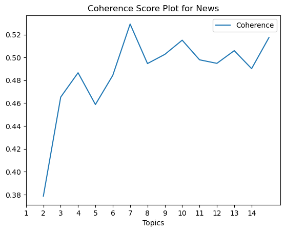

```python
news_lda_tuning = lda_tuning[lda_tuning['Corpus'] == 'News']
news_lda_tuning.plot(
    x ='Topics',
    y='Coherence',
    title='Coherence Score Plot for News',
    kind = 'line',
    xticks=range(1,15))
```

```python
lda_tuning[lda_tuning['Corpus'] == 'Tweets']
```

|  | Topics | Alpha | Beta | Coherence | Corpus |
| --- | --- | --- | --- | --- | --- |
| 0 | 2 | asymmetric | auto | 0.156878 | Tweets |
| 1 | 3 | asymmetric | auto | 0.263000 | Tweets |
| 2 | 4 | asymmetric | auto | 0.301967 | Tweets |
| 3 | 5 | asymmetric | auto | 0.314795 | Tweets |
| 4 | 6 | asymmetric | auto | 0.405001 | Tweets |
| 5 | 7 | asymmetric | auto | 0.347038 | Tweets |
| 6 | 8 | asymmetric | auto | 0.392396 | Tweets |
| 7 | 9 | asymmetric | auto | 0.393379 | Tweets |
| 8 | 10 | asymmetric | auto | 0.351710 | Tweets |
| 9 | 11 | asymmetric | auto | 0.434388 | Tweets |
| 10 | 12 | asymmetric | auto | 0.392594 | Tweets |
| 11 | 13 | asymmetric | auto | 0.367232 | Tweets |
| 12 | 14 | asymmetric | auto | 0.407031 | Tweets |
| 13 | 15 | asymmetric | auto | 0.381520 | Tweets |

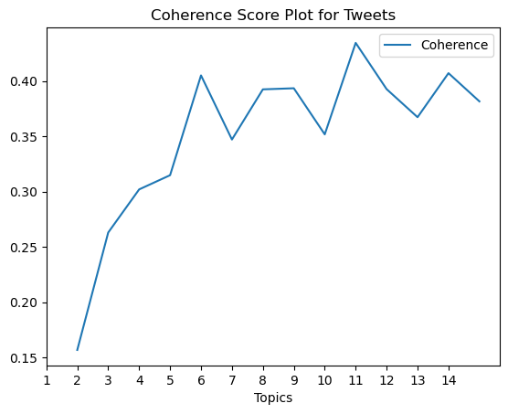

```python
tweets_lda_tuning = lda_tuning[lda_tuning['Corpus'] == 'Tweets']
tweets_lda_tuning.plot(
    x ='Topics',
    y='Coherence',
    title='Coherence Score Plot for Tweets',
    kind = 'line',
    xticks=range(1,15))
```

#### Explain how you selected N

The selection of 'N', the number of topics for the Latent Dirichlet Allocation (LDA) model, is a crucial step in topic modeling that can significantly influence the interpretability and coherence of the resulting topics. To assess the quality of the topics generated by the model, the coherence score was calculated for each topic. Coherence scores help in evaluating how meaningful the topics are, based on the semantic similarity between the high scoring words in each topic.

In this case we selected 'N' = 7, so 7 topics for news (which is title and text combined) and 'N' = 6, so 6 topics for tweets based on coherence scores and where the coherence scores was high. Incase where coherence scores were close to each other we choose the smaller N to allow the model to be less complex.

Note: This is based on coherence score above but we will look at those tuned model and then the topic visulation to see if we need to further tweak our code and select a different N

#### Running the best model for News

```python
news_lda_tuning = lda_tuning[lda_tuning['Corpus'] == 'News']
news_lda_tuning_best = news_lda_tuning.sort_values(by=['Coherence'], ascending=False).head(1)
news_tuned_topics = int(news_lda_tuning_best['Topics'].to_string(index=False))
# Since the values for Alpha and Beta can be float, symmetric and asymmetric
# we will either strip or convert to float
try:
    news_tuned_alpha = float(news_lda_tuning_best['Alpha'].to_string(index=False))
except:
    news_tuned_alpha = news_lda_tuning_best['Alpha'].to_string(index=False).strip()
try:
    news_tuned_beta = float(news_lda_tuning_best['Beta'].to_string(index=False))
except:
    news_tuned_beta = news_lda_tuning_best['Beta'].to_string(index=False).strip()

print(f'Best Parameters: Topics: {news_tuned_topics}, Alpha: {news_tuned_alpha}, Beta: {news_tuned_beta}')
```

```
Best Parameters: Topics: 7, Alpha: asymmetric, Beta: auto
```

```python
%%time

news_tuned_lda_model = LdaMulticore(corpus = news_corpus,
                                    id2word = news_dictionary,
                                    num_topics = news_tuned_topics,
                                    random_state = 123,
                                    passes = 10,
                                    alpha = news_tuned_alpha,
                                    eta = news_tuned_beta,
                                    workers = multiprocessing.cpu_count())

news_coherence_model_lda = CoherenceModel(model = news_tuned_lda_model,
                                          texts = news_lemmatized,
                                          dictionary = news_dictionary,
                                          coherence = 'c_v')

print('\nCoherence Score: ', news_coherence_model_lda)
```

```
Coherence Score:  Coherence_Measure(seg=<function s_one_set at 0x7fc88dc605e0>, prob=<function p_boolean_sliding_window at 0x7fc88dc60790>, conf=<function cosine_similarity at 0x7fc88dcba670>, aggr=<function arithmetic_mean at 0x7fc88dcbac10>)
CPU times: user 2min 51s, sys: 57.3 s, total: 3min 48s
Wall time: 2min 30s
```

```python
print(*news_tuned_lda_model.print_topics(num_topics=news_tuned_topics, num_words=7), sep='\n\n')
```

```
(0, '0.010*"market" + 0.006*"business" + 0.005*"datum" + 0.005*"technology" + 0.004*"global" + 0.004*"report" + 0.004*"stock"')

(1, '0.005*"game" + 0.005*"open" + 0.004*"work" + 0.004*"review" + 0.004*"feature" + 0.004*"video" + 0.003*"need"')

(2, '0.017*"stock" + 0.008*"quarter" + 0.008*"product" + 0.008*"price" + 0.006*"rating" + 0.006*"last" + 0.006*"report"')

(3, '0.015*"market" + 0.009*"stock" + 0.005*"price" + 0.005*"cookie" + 0.005*"report" + 0.004*"high" + 0.004*"user"')

(4, '0.006*"ago" + 0.006*"game" + 0.005*"people" + 0.005*"show" + 0.004*"more" + 0.004*"music" + 0.004*"look"')

(5, '0.057*"video" + 0.057*"music" + 0.053*"official" + 0.011*"song" + 0.007*"covid" + 0.007*"game" + 0.006*"full"')

(6, '0.006*"video" + 0.005*"show" + 0.004*"covid" + 0.004*"music" + 0.003*"official" + 0.003*"state" + 0.003*"reveal"')
```

```python
lda_display = gensimvis.prepare(news_tuned_lda_model,
                                news_corpus,
                                news_dictionary,
                                sort_topics=False,
                                mds='mmds',
                                n_jobs=1)
pyLDAvis.display(lda_display)
```

[interactive chart not shown]

### For news we had combined title and text, N = 7 topics are picked based on the coherence score. The topics likley are:

1. Related to market, business, technology, global report
2. Related to open game review, some feature / update
3. Related to product, price, rating
4. Related to finance - market, stock, price, report
5. Related to game show, people, video reveal
6. Related to offical music video / song
7. Related to off-topics like covid, police, state

#### Running the best model for Tweets

```python
# We need to manually enter these details since we are going with a lower N but similar coherence score to make topic model less complex
tweets_lda_tuning = lda_tuning[lda_tuning['Corpus'] == 'Tweets']
tweets_lda_tuning_best = tweets_lda_tuning.sort_values(by=['Coherence'], ascending=False).head(1)
tweets_tuned_topics = 6
tweets_tuned_alpha = 'asymmetric'
tweets_tuned_beta = 'auto'

print(f'Best Parameters: Topics: {tweets_tuned_topics}, Alpha: {tweets_tuned_alpha}, Beta: {tweets_tuned_beta}')
```

```
Best Parameters: Topics: 6, Alpha: asymmetric, Beta: auto
```

```python
%%time

tweets_tuned_lda_model = LdaMulticore(corpus = tweets_corpus,
                                      id2word = tweets_dictionary,
                                      num_topics = tweets_tuned_topics,
                                      random_state = 123,
                                      passes = 10,
                                      alpha = tweets_tuned_alpha,
                                      eta = tweets_tuned_beta,
                                      workers = multiprocessing.cpu_count())

tweets_coherence_model_lda = CoherenceModel(model = tweets_tuned_lda_model,
                                          texts = tweets_lemmatized,
                                          dictionary = tweets_dictionary,
                                          coherence = 'c_v')

print('\nCoherence Score: ', tweets_coherence_model_lda)
```

```
Coherence Score:  Coherence_Measure(seg=<function s_one_set at 0x7fc88dc605e0>, prob=<function p_boolean_sliding_window at 0x7fc88dc60790>, conf=<function cosine_similarity at 0x7fc88dcba670>, aggr=<function arithmetic_mean at 0x7fc88dcbac10>)
CPU times: user 10.5 s, sys: 2.84 s, total: 13.4 s
Wall time: 46.9 s
```

```python
print(*tweets_tuned_lda_model.print_topics(num_topics=tweets_tuned_topics, num_words=7), sep='\n\n')
```

```
(0, '0.010*"azure" + 0.008*"use" + 0.008*"word" + 0.007*"learn" + 0.006*"business" + 0.006*"get" + 0.006*"new"')

(1, '0.013*"year" + 0.011*"new" + 0.010*"microsoft" + 0.010*"company" + 0.007*"buy" + 0.007*"get" + 0.006*"twitter"')

(2, '0.116*"ever" + 0.026*"team" + 0.021*"use" + 0.012*"make" + 0.011*"game" + 0.009*"work" + 0.009*"know"')

(3, '0.014*"use" + 0.011*"make" + 0.008*"playstation" + 0.008*"game" + 0.008*"company" + 0.007*"week" + 0.007*"stock"')

(4, '0.021*"window" + 0.018*"game" + 0.017*"get" + 0.016*"new" + 0.007*"well" + 0.007*"more" + 0.007*"free"')

(5, '0.025*"buy" + 0.024*"spotify" + 0.018*"grammarly" + 0.017*"game" + 0.014*"youtube" + 0.014*"premium" + 0.012*"make"')
```

```python
lda_display = gensimvis.prepare(tweets_tuned_lda_model,
                                tweets_corpus,
                                tweets_dictionary,
                                sort_topics=False,
                                mds='mmds',
                                n_jobs=1)
pyLDAvis.display(lda_display)
```

[interactive chart not shown]

### For tweets, N = 6 topics are picked based on the coherence score. The topics likley are:

1. Related to Microsoft and its products like azure, word, office, cybersecurity
2. Related to buy company, new year, twitter
3. Related to use microsoft team
4. Related to playstation game, acquistion, browser
5. Related to windows, game, free, gaming
6. Related to premium subscriptions likely on spotify, grammarly, youtube

Clearly the company is Microsoft and tweets are likely about the company, it's acquistions/deals, its app ecosystem, and products.